```r
data <- read.csv('./vgsales.csv')
library(tidyverse)
```

##1. Pitanje: Jesu li u Japanu RPG igre znčajno prodavanije od FPS igara? Možete li pronaći neki žanr koji je značajno popularniji u Europi nego u Japanu?

#Jesu li u Japanu RPG igre značajno prodavanije od FPS igara?

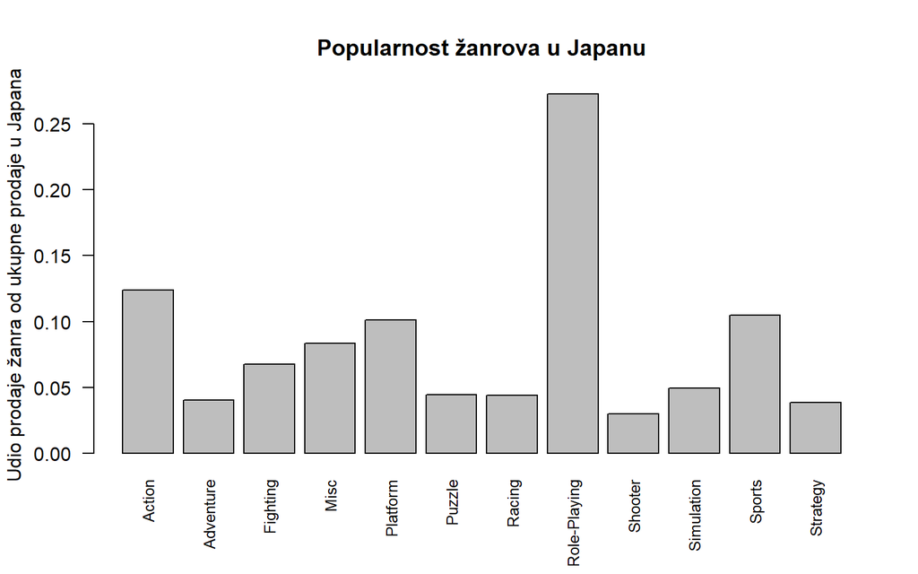

```r
# Pogledajmo prvo podatke koje imam o Japanu prije same uspostave test
# Za usporedbu po žanrovima koristiti ćemo udio prodaje žanra u Japanu od ukupnih prodaja u Japanu.

JPGenreSales = data[c(5,9)]

JapanProfitByGenre = JPGenreSales %>% group_by(Genre) %>%
                     summarise(PercentageOfGenreInMarket = sum(JP_Sales) / sum(JPGenreSales$JP_Sales))


barplot(JapanProfitByGenre$PercentageOfGenreInMarket,
        names.arg = JapanProfitByGenre$Genre,
        las = 2,
        cex.names = 0.8,
        main = "Popularnost žanrova u Japanu",
        ylab = "Udio prodaje žanra od ukupne prodaje u Japana")
```

Na prvi pogled izgleda kao da su RPG igre znatno dominantan žanr u Japanu te svakako popularnije od FPS igri. Uvjerimo se u to prikazivanjem podataka pomoću i drugih grafova.

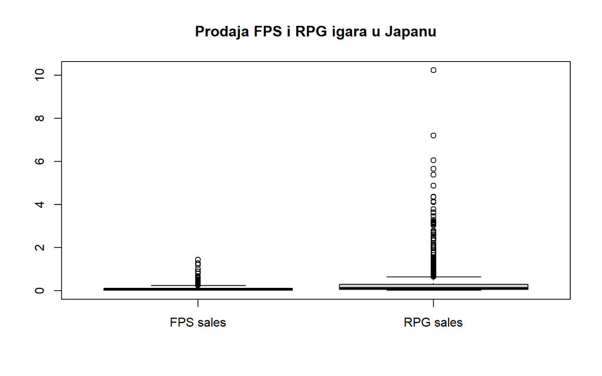

```r
JP_FPSData = JPGenreSales[JPGenreSales$Genre == "Shooter" & JPGenreSales$JP_Sale > 0, ]
JP_RPGData = JPGenreSales[JPGenreSales$Genre == "Role-Playing" & JPGenreSales$JP_Sales > 0, ]


boxplot(JP_FPSData$JP_Sales, JP_RPGData$JP_Sales,
        names = c("FPS sales", "RPG sales"),
        main = "Prodaja FPS i RPG igara u Japanu")
```

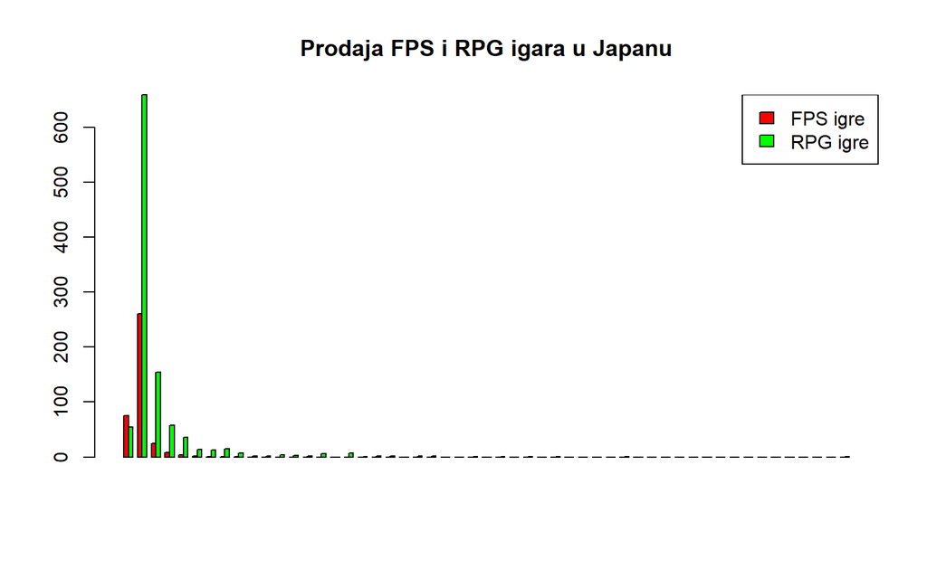

```r
b = seq(min(JP_RPGData$JP_Sales) - 0.2,max(JP_RPGData$JP_Sales) + 0.2,0.2)

h1 = hist(JP_FPSData$JP_Sales, breaks = b, plot = FALSE)
h2 = hist(JP_RPGData$JP_Sales, breaks = b, plot = FALSE)

JP_RPGFPSdata <- t(cbind(h1$counts, h2$counts))

barplot(JP_RPGFPSdata, beside=TRUE, col = c("red", "green"),
        main = "Prodaja FPS i RPG igara u Japanu")
legend("topright", fill = c("red", "green"), c("FPS igre", "RPG igre"))
```

Nažalost podatci sadrže ogroman broj niskoprodavanih igrica te time je svaka imalo uspješna igrica “outlier”. Posljedica je jako nečitljiv box-and-whisker graf i gotovo nevidljivi outlieri na bar grafu. Zato ćemo iz naših podataka izbaciti najnižih i najviših 10% vrijednosti.

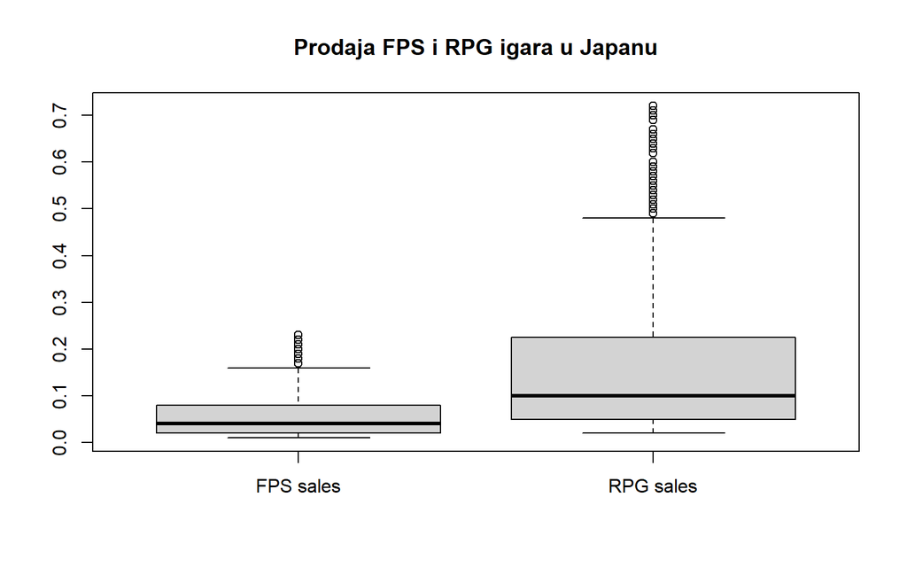

```r
JP_FPSq <- quantile(JP_FPSData$JP_Sales, probs = c(.1, .90))
JP_RPGq <- quantile(JP_RPGData$JP_Sales, probs = c(.1, .90))

JP_FPSDataTrimmed = JPGenreSales[JPGenreSales$Genre == "Shooter"
                              & JPGenreSales$JP_Sales >= JP_FPSq[1] & JPGenreSales$JP_Sales <= JP_FPSq[2], ]
JP_RPGDataTrimmed = JPGenreSales[JPGenreSales$Genre == "Role-Playing"
                              & JPGenreSales$JP_Sales >= JP_RPGq[1] & JPGenreSales$JP_Sales <= JP_RPGq[2], ]

bTrimmed = seq(min(JP_RPGDataTrimmed$JP_Sales) - 0.05,max(JP_RPGDataTrimmed$JP_Sales) + 0.05,0.05)

boxplot(JP_FPSDataTrimmed$JP_Sales, JP_RPGDataTrimmed$JP_Sales,
        names = c("FPS sales", "RPG sales"),
        main = "Prodaja FPS i RPG igara u Japanu")
```

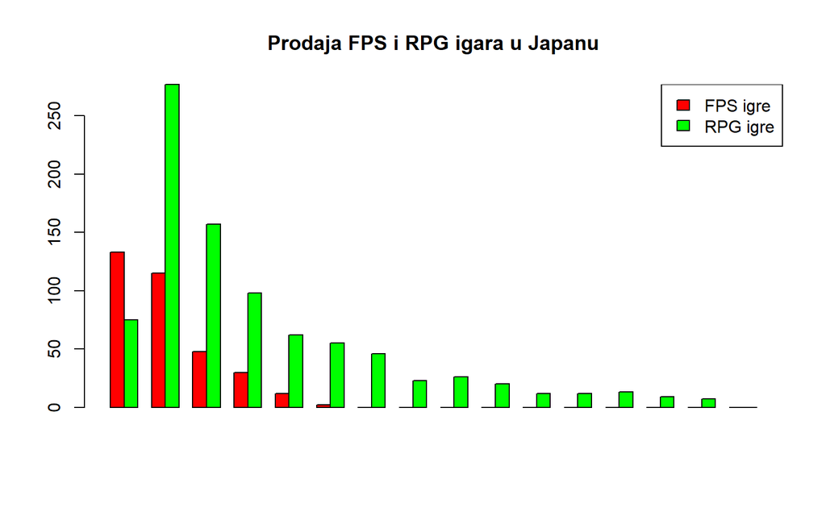

```r
h1Trimmed = hist(JP_FPSDataTrimmed$JP_Sales, breaks = bTrimmed, plot = FALSE)
h2Trimmed = hist(JP_RPGDataTrimmed$JP_Sales, breaks = bTrimmed, plot = FALSE)

JP_RPGFPSdataTrimmed <- t(cbind(h1Trimmed$counts, h2Trimmed$counts))

barplot(JP_RPGFPSdataTrimmed, beside=TRUE, col = c("red", "green"),
        main = "Prodaja FPS i RPG igara u Japanu",)
legend("topright", fill = c("red", "green"), c("FPS igre", "RPG igre"))
```

Iz novih grafova možemo uočiti nekoliko stvari: U Japanu se izlazi puno više novih RPG nego FPS igri. U prosjeku RPG igre su puno prodavanije od FPS igri. RPG igre imaju puno više jako prodavanih outliera te su oni i znatno prodavaniji od FPS outliera. Možemo zaključiti da su RPG igre popularnije od FPS igri u Japanu.

#Možete li pronaći neki žanr koji je značajno popularniji u Europi nego u Japanu?

Prije nego krenemo na rješavanje samog pitanja moramo razriješiti problem popularnosti. Kako je Europsko tržište znatno veće nego Japan moramo odabrati model koji će dobro opisati “popularnost” žanrova neovisno o populaciji potrošača. Model koji smo izabrali jest udio potrošača žanra od ukupnih potrošača regije, tj.: npr. popularnost RPG igara u Japanu odredit ćemo tako da broj prodaja RPG igara Japana podijelimo s brojem prodaje svih žanrova Japana.

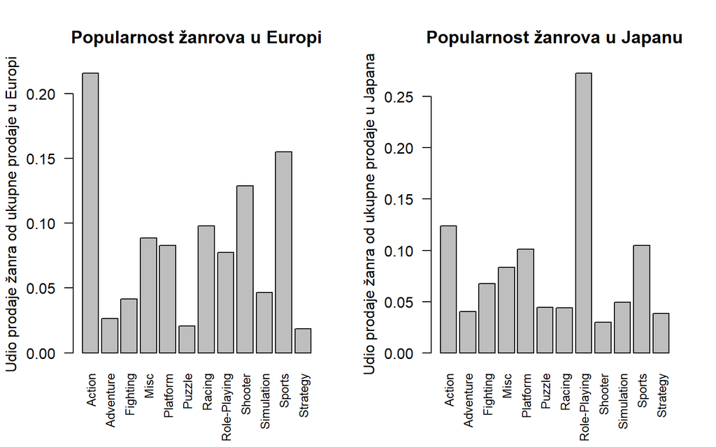

```r
#Prikažimo prvo podatke grafički bar grafovima

EUGenreSales = data[c(5,8)]

EuropeProfitByGenre = EUGenreSales %>% group_by(Genre) %>%
                     summarise(PercentageOfGenreInMarket = sum(EU_Sales) / sum(EUGenreSales$EU_Sales))

par(mfrow=c(1,2))

barplot(EuropeProfitByGenre$PercentageOfGenreInMarket,
        names.arg = EuropeProfitByGenre$Genre,
        las = 2,
        cex.names = 0.8,
        main = "Popularnost žanrova u Europi",
        ylab = "Udio prodaje žanra od ukupne prodaje u Europi")

barplot(JapanProfitByGenre$PercentageOfGenreInMarket,
        names.arg = JapanProfitByGenre$Genre,
        las = 2,
        cex.names = 0.8,
        main = "Popularnost žanrova u Japanu",
        ylab = "Udio prodaje žanra od ukupne prodaje u Japana")
```

Možemo uočiti nekoliko žanrova koji su popularniji u Europi nego u Japanu prema izabranom modelu. To su žanrovi: Action, Racing, Shooter, Sports. Prikažimo dodatne grafove za žanr Shooter.

[figure not shown]

```r
#Odmah ćemo koristiti srezane podatke
EU_FPSData = EUGenreSales[EUGenreSales$Genre == "Shooter" & EUGenreSales$EU_Sales > 0, ]

EU_FPSq <- quantile(EU_FPSData$EU_Sales, probs = c(.1, .90))

EU_FPSDataTrimmed = EUGenreSales[EUGenreSales$Genre == "Shooter"
                        & EUGenreSales$EU_Sales >= EU_FPSq[1] & EUGenreSales$EU_Sales <= EU_FPSq[2], ]

boxplot(EU_FPSDataTrimmed$EU_Sales, JP_FPSDataTrimmed$JP_Sales,
        names = c("EU FPS sales", "Japan RPG sales"),
        main = "Prodaja FPS igri u EU i Japanu")
```

[figure not shown]

```r
bJPvEU = seq(min(JP_FPSData$JP_Sales) - 0.05,max(JP_FPSData$JP_Sales)-0.6,0.05)

h1 = hist(JP_FPSDataTrimmed$JP_Sales, breaks = bJPvEU, plot = FALSE)
h2 = hist(EU_FPSDataTrimmed$EU_Sales, breaks = bJPvEU, plot = FALSE)

JPEU_FPSdataTrimmed <- t(cbind(h1$counts, h2$counts))

barplot(JPEU_FPSdataTrimmed, beside=TRUE, col = c("red", "green"),
        main = "Prodaja FPS i RPG igara u Japanu")
legend("topright", fill = c("red", "green"), c("FPS igre", "RPG igre"))
```

Iz navedenih grafova možemo se uvjeriti da su FPS igre popularnije u Europi nego Japanu i po broju naslova i po prodajama.

##2. Pitanje: Promatrajući prodaju u Sjevernoj Americi, jesu li neki žanrovi značajno popularniji?

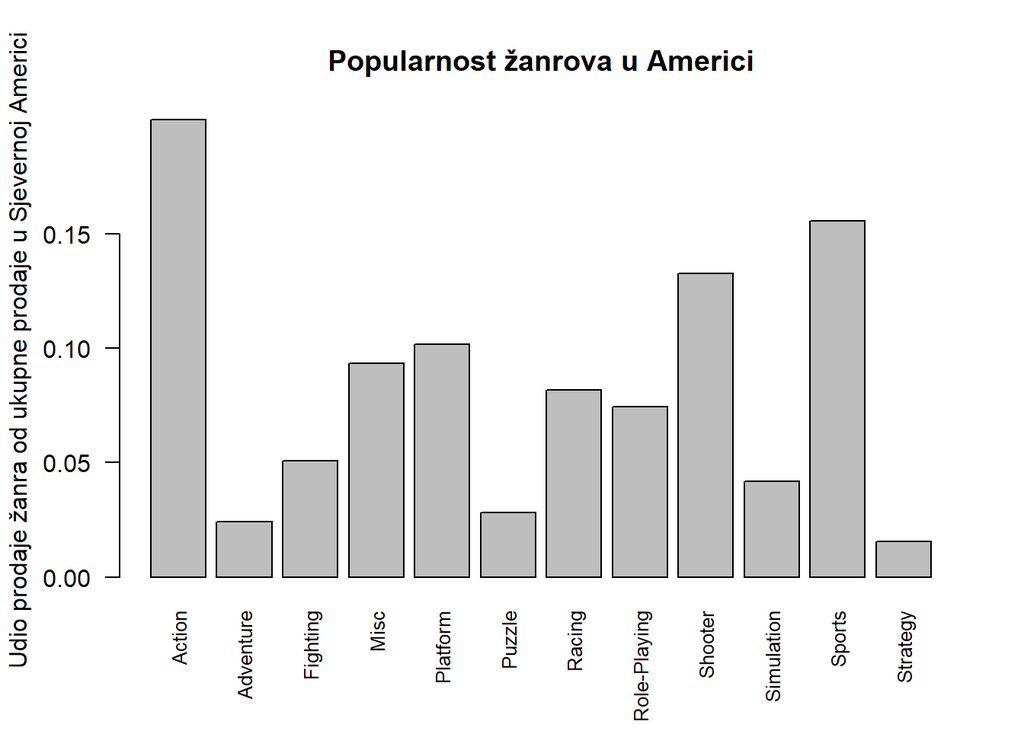

```r
# Gledamo prvo podatke koje imam o Sjevernoj Americi prije testa
# Za usporedbu po žanrovima koristiti ćemo udio prodaje žanrova u Americi od ukupne prodaje u Americi.

NAGenreSales = data[c(5,7)]
NAProfitByGenre = NAGenreSales %>% group_by(Genre) %>%
                     summarise(PercentageOfGenreInMarket = sum(NA_Sales) / sum(NAGenreSales$NA_Sales))
barplot(NAProfitByGenre$PercentageOfGenreInMarket,
        names.arg = NAProfitByGenre$Genre,
        las = 2,
        cex.names = 0.8,
        main = "Popularnost žanrova u Americi",
        ylab = "Udio prodaje žanra od ukupne prodaje u Sjevernoj Americi")
```

Odokativno vidimo da su prodavaniji žanrovi Action, Shooter i Sports, te da se žanrovi Strategy, Adventure i Puzzle slabije prodaju.